# ARIMA Assignment

```r
library(fpp)
library(fpp2)
```

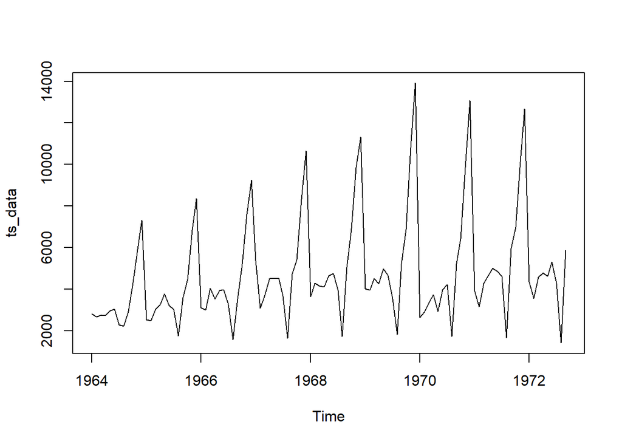

```r
df <- read.csv("C:\\Users\\rusha\\Downloads\\BF\\HW files\\perrin-freres-monthly-champagne-.csv")
df_s<-df$Sales
columns_to_convert <- c("Year", "Month")
df[columns_to_convert] <- lapply(df[columns_to_convert], as.character)
time_index <- as.Date(paste(df$Year, df$Month, "01", sep = "-"))
ts_data <- ts(df$Sales, start = c(min(df$Year), min(df$Month)), frequency = 12)
plot(ts_data)
```

Output

The time series data is seasonal

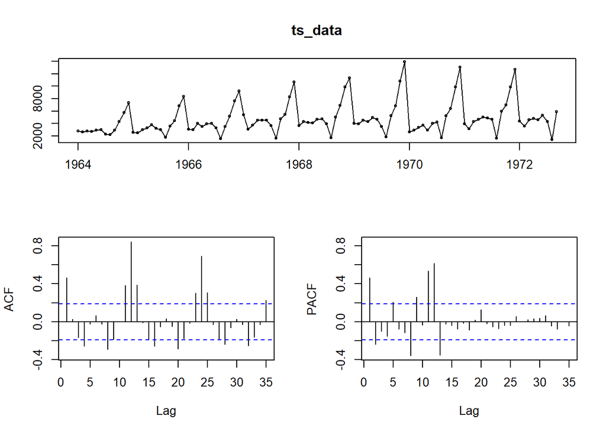

```r
tsdisplay(ts_data)
```

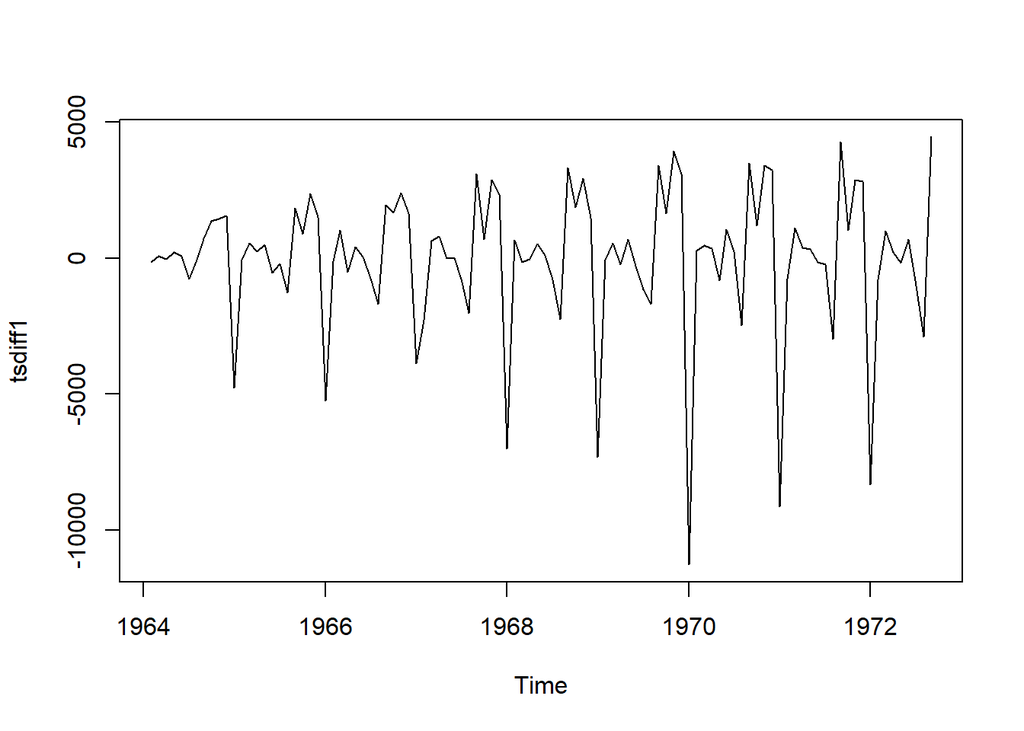

```r
tsdiff1 <- diff(ts_data, differences = 1)
plot(tsdiff1)
```

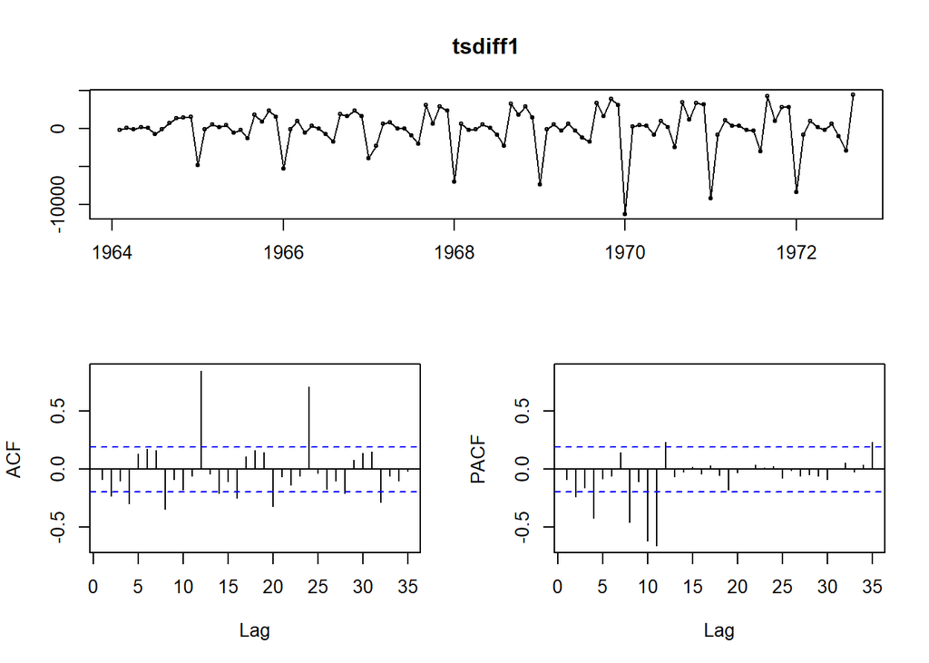

```r
tsdisplay(tsdiff1)
```

Significant spike at lag 12 and 24 in the Acf plot. Pacf plot also has spikes.

```r
auto_fit <- auto.arima(ts_data, trace=TRUE, stepwise = FALSE)
```

```
##
##  ARIMA(0,0,0)(0,1,0)[12]                    : 1511.315
##  ARIMA(0,0,0)(0,1,0)[12] with drift         : 1501.017
##  ARIMA(0,0,0)(0,1,1)[12]                    : 1512.878
##  ARIMA(0,0,0)(0,1,1)[12] with drift         : 1498.534
##  ARIMA(0,0,0)(0,1,2)[12]                    : 1512.916
##  ARIMA(0,0,0)(0,1,2)[12] with drift         : 1500.564
##  ARIMA(0,0,0)(1,1,0)[12]                    : 1512.727
##  ARIMA(0,0,0)(1,1,0)[12] with drift         : 1498.23
##  ARIMA(0,0,0)(1,1,1)[12]                    : Inf
##  ARIMA(0,0,0)(1,1,1)[12] with drift         : 1500.23
##  ARIMA(0,0,0)(1,1,2)[12]                    : Inf
##  ARIMA(0,0,0)(1,1,2)[12] with drift         : Inf
##  ARIMA(0,0,0)(2,1,0)[12]                    : 1512.712
##  ARIMA(0,0,0)(2,1,0)[12] with drift         : 1500.349
##  ARIMA(0,0,0)(2,1,1)[12]                    : Inf
##  ARIMA(0,0,0)(2,1,1)[12] with drift         : Inf
##  ARIMA(0,0,0)(2,1,2)[12]                    : Inf
##  ARIMA(0,0,0)(2,1,2)[12] with drift         : Inf
##  ARIMA(0,0,1)(0,1,0)[12]                    : 1505.592
##  ARIMA(0,0,1)(0,1,0)[12] with drift         : 1499.117
##  ARIMA(0,0,1)(0,1,1)[12]                    : 1504.874
##  ARIMA(0,0,1)(0,1,1)[12] with drift         : 1494.344
##  ARIMA(0,0,1)(0,1,2)[12]                    : 1504.588
##  ARIMA(0,0,1)(0,1,2)[12] with drift         : 1496.087
##  ARIMA(0,0,1)(1,1,0)[12]                    : 1503.898
##  ARIMA(0,0,1)(1,1,0)[12] with drift         : 1493.463
##  ARIMA(0,0,1)(1,1,1)[12]                    : Inf
##  ARIMA(0,0,1)(1,1,1)[12] with drift         : 1495.331
##  ARIMA(0,0,1)(1,1,2)[12]                    : Inf
##  ARIMA(0,0,1)(1,1,2)[12] with drift         : Inf
##  ARIMA(0,0,1)(2,1,0)[12]                    : 1504.078
##  ARIMA(0,0,1)(2,1,0)[12] with drift         : 1495.502
##  ARIMA(0,0,1)(2,1,1)[12]                    : Inf
##  ARIMA(0,0,1)(2,1,1)[12] with drift         : 1497.929
##  ARIMA(0,0,1)(2,1,2)[12]                    : Inf
##  ARIMA(0,0,1)(2,1,2)[12] with drift         : Inf
##  ARIMA(0,0,2)(0,1,0)[12]                    : 1506.559
##  ARIMA(0,0,2)(0,1,0)[12] with drift         : 1501.075
##  ARIMA(0,0,2)(0,1,1)[12]                    : 1505.175
```

[output cut: 142 more lines]

```
##  ARIMA(3,0,2)(0,1,0)[12] with drift         : Inf
##  ARIMA(4,0,0)(0,1,0)[12]                    : 1506.56
##  ARIMA(4,0,0)(0,1,0)[12] with drift         : 1504.41
##  ARIMA(4,0,0)(0,1,1)[12]                    : 1504.324
##  ARIMA(4,0,0)(0,1,1)[12] with drift         : 1500.01
##  ARIMA(4,0,0)(1,1,0)[12]                    : 1503.49
##  ARIMA(4,0,0)(1,1,0)[12] with drift         : 1499.308
##  ARIMA(4,0,1)(0,1,0)[12]                    : 1508.786
##  ARIMA(4,0,1)(0,1,0)[12] with drift         : 1506.635
##  ARIMA(5,0,0)(0,1,0)[12]                    : 1508.778
##  ARIMA(5,0,0)(0,1,0)[12] with drift         : 1506.173
##
##
##
##  Best model: ARIMA(1,0,0)(1,1,0)[12] with drift
```

Output summary

ARIMA(1,0,0)(1,1,0)[12] with drift: (1,0,0) represents the non-seasonal part of the model. The model includes one lag of the dependent variable

(1,1,0) represents the seasonal part of the model. Indicates that first differences are taken at seasonal lag 12 because it is a monthly data with a seasonality of [12]

with drift: indicates that the model includes a drift term. The model indicates that it considers the influence of both recent values and values from the same season in the previous year.

```r
auto_fit
```

```
## Series: ts_data
## ARIMA(1,0,0)(1,1,0)[12] with drift
##
## Coefficients:
##          ar1     sar1    drift
##       0.2881  -0.2920  23.8994
## s.e.  0.1017   0.0988   6.7756
##
## sigma^2 = 510556:  log likelihood = -742.18
## AIC=1492.35   AICc=1492.81   BIC=1502.48
```

```r
attributes(auto_fit)
```

```
## $names
##  [1] "coef"      "sigma2"    "var.coef"  "mask"      "loglik"    "aic"
##  [7] "arma"      "residuals" "call"      "series"    "code"      "n.cond"
## [13] "nobs"      "model"     "xreg"      "bic"       "aicc"      "x"
## [19] "fitted"
##
## $class
## [1] "forecast_ARIMA" "ARIMA"          "Arima"
```

Q3) Perform and Plot the forecast for the next five periods

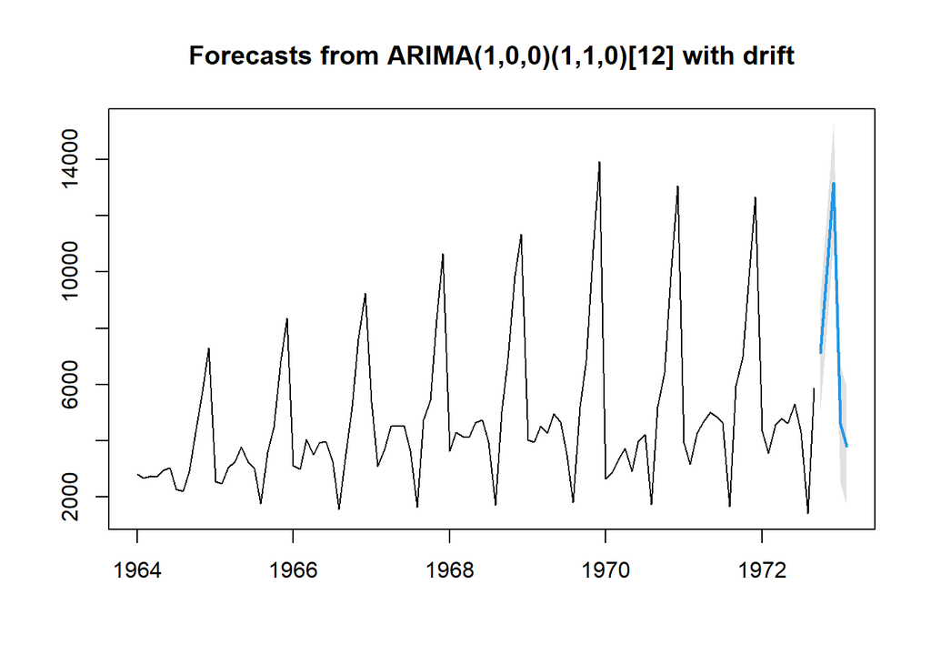

```r
plot(forecast(auto_fit,h=5,level=c(99.5)))
```

Q2) Residual analysis

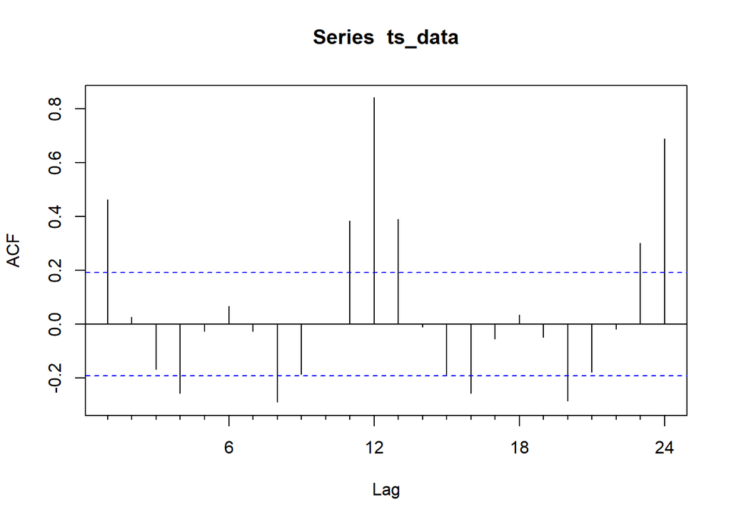

```r
Acf(ts_data)
```

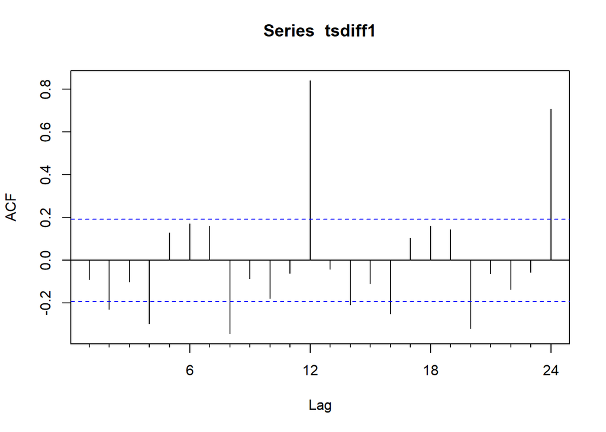

```r
Acf(tsdiff1)
```

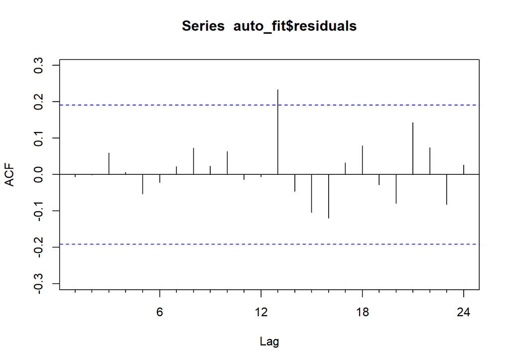

```r
Acf(auto_fit$residuals)
```

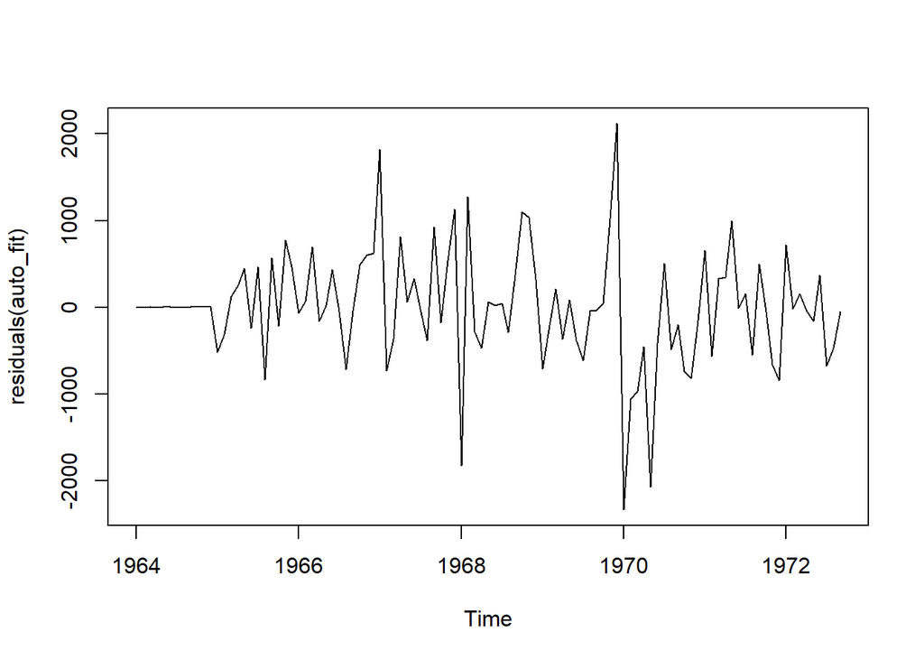

```r
plot.ts(residuals(auto_fit))
```

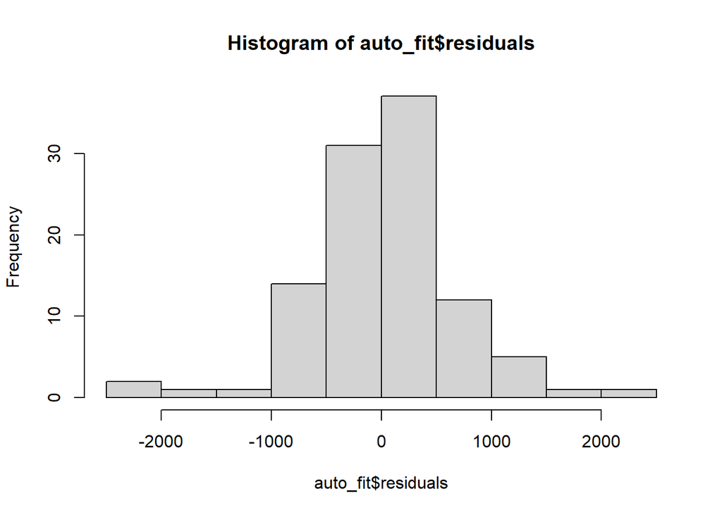

```r
hist(auto_fit$residuals)
```

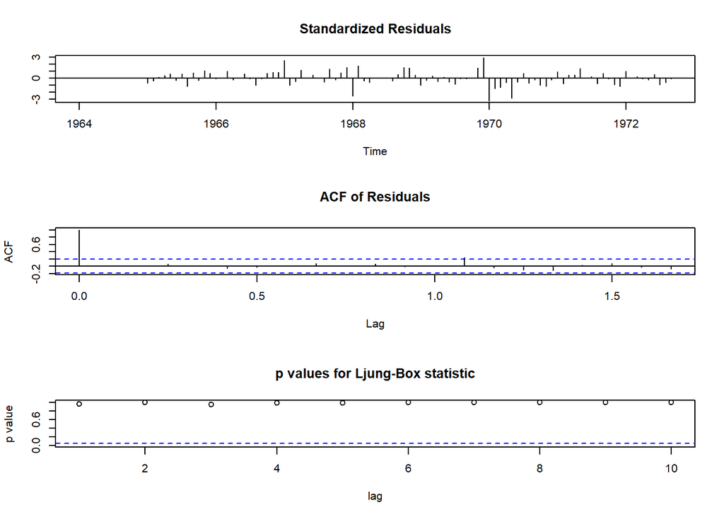

```r
tsdiag(auto_fit)
```

```r
nsdiffs(ts_data)
```

```
## [1] 1
```

```r
ndiffs(ts_data)
```

```
## [1] 1
```

```r
ndiffs(diff(ts_data,4))
```

```
## [1] 0
```

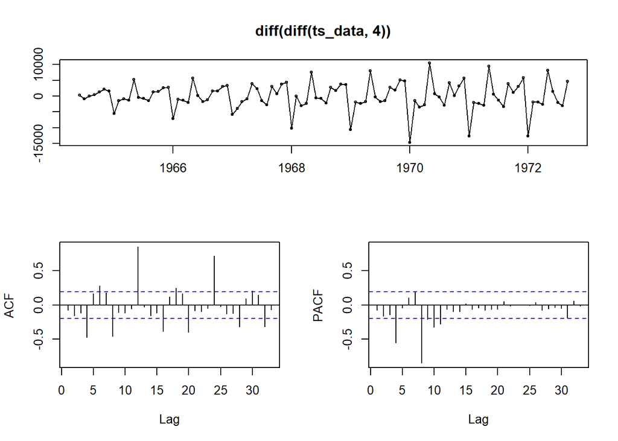

```r
tsdisplay(diff(diff(ts_data,4)))
```

Significant spikes in the Acf plot at lags 4,8,12,16,20.. and Pacf plots at lags 4 and 8

```r
fit3 <- auto.arima(ts_data,trace=TRUE, stepwise = FALSE )
```

```
##
##  ARIMA(0,0,0)(0,1,0)[12]                    : 1511.315
##  ARIMA(0,0,0)(0,1,0)[12] with drift         : 1501.017
##  ARIMA(0,0,0)(0,1,1)[12]                    : 1512.878
##  ARIMA(0,0,0)(0,1,1)[12] with drift         : 1498.534
##  ARIMA(0,0,0)(0,1,2)[12]                    : 1512.916
##  ARIMA(0,0,0)(0,1,2)[12] with drift         : 1500.564
##  ARIMA(0,0,0)(1,1,0)[12]                    : 1512.727
##  ARIMA(0,0,0)(1,1,0)[12] with drift         : 1498.23
##  ARIMA(0,0,0)(1,1,1)[12]                    : Inf
##  ARIMA(0,0,0)(1,1,1)[12] with drift         : 1500.23
##  ARIMA(0,0,0)(1,1,2)[12]                    : Inf
##  ARIMA(0,0,0)(1,1,2)[12] with drift         : Inf
##  ARIMA(0,0,0)(2,1,0)[12]                    : 1512.712
##  ARIMA(0,0,0)(2,1,0)[12] with drift         : 1500.349
##  ARIMA(0,0,0)(2,1,1)[12]                    : Inf
##  ARIMA(0,0,0)(2,1,1)[12] with drift         : Inf
##  ARIMA(0,0,0)(2,1,2)[12]                    : Inf
##  ARIMA(0,0,0)(2,1,2)[12] with drift         : Inf
##  ARIMA(0,0,1)(0,1,0)[12]                    : 1505.592
##  ARIMA(0,0,1)(0,1,0)[12] with drift         : 1499.117
##  ARIMA(0,0,1)(0,1,1)[12]                    : 1504.874
##  ARIMA(0,0,1)(0,1,1)[12] with drift         : 1494.344
##  ARIMA(0,0,1)(0,1,2)[12]                    : 1504.588
##  ARIMA(0,0,1)(0,1,2)[12] with drift         : 1496.087
##  ARIMA(0,0,1)(1,1,0)[12]                    : 1503.898
##  ARIMA(0,0,1)(1,1,0)[12] with drift         : 1493.463
##  ARIMA(0,0,1)(1,1,1)[12]                    : Inf
##  ARIMA(0,0,1)(1,1,1)[12] with drift         : 1495.331
##  ARIMA(0,0,1)(1,1,2)[12]                    : Inf
##  ARIMA(0,0,1)(1,1,2)[12] with drift         : Inf
##  ARIMA(0,0,1)(2,1,0)[12]                    : 1504.078
##  ARIMA(0,0,1)(2,1,0)[12] with drift         : 1495.502
##  ARIMA(0,0,1)(2,1,1)[12]                    : Inf
##  ARIMA(0,0,1)(2,1,1)[12] with drift         : 1497.929
##  ARIMA(0,0,1)(2,1,2)[12]                    : Inf
##  ARIMA(0,0,1)(2,1,2)[12] with drift         : Inf
##  ARIMA(0,0,2)(0,1,0)[12]                    : 1506.559
##  ARIMA(0,0,2)(0,1,0)[12] with drift         : 1501.075
##  ARIMA(0,0,2)(0,1,1)[12]                    : 1505.175
```

[output cut: 142 more lines]

```
##  ARIMA(3,0,2)(0,1,0)[12] with drift         : Inf
##  ARIMA(4,0,0)(0,1,0)[12]                    : 1506.56
##  ARIMA(4,0,0)(0,1,0)[12] with drift         : 1504.41
##  ARIMA(4,0,0)(0,1,1)[12]                    : 1504.324
##  ARIMA(4,0,0)(0,1,1)[12] with drift         : 1500.01
##  ARIMA(4,0,0)(1,1,0)[12]                    : 1503.49
##  ARIMA(4,0,0)(1,1,0)[12] with drift         : 1499.308
##  ARIMA(4,0,1)(0,1,0)[12]                    : 1508.786
##  ARIMA(4,0,1)(0,1,0)[12] with drift         : 1506.635
##  ARIMA(5,0,0)(0,1,0)[12]                    : 1508.778
##  ARIMA(5,0,0)(0,1,0)[12] with drift         : 1506.173
##
##
##
##  Best model: ARIMA(1,0,0)(1,1,0)[12] with drift
```

```r
fit3
```

```
## Series: ts_data
## ARIMA(1,0,0)(1,1,0)[12] with drift
##
## Coefficients:
##          ar1     sar1    drift
##       0.2881  -0.2920  23.8994
## s.e.  0.1017   0.0988   6.7756
##
## sigma^2 = 510556:  log likelihood = -742.18
## AIC=1492.35   AICc=1492.81   BIC=1502.48
```

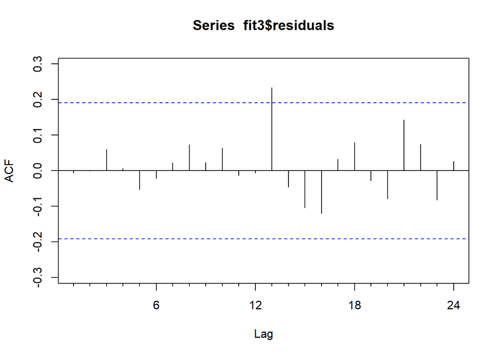

```r
Acf(fit3$residuals)
```

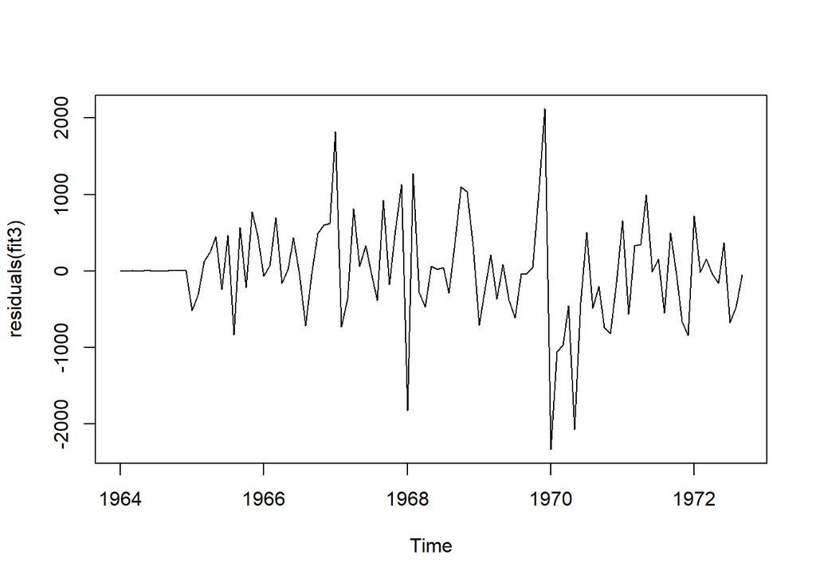

```r
plot.ts(residuals(fit3))
```

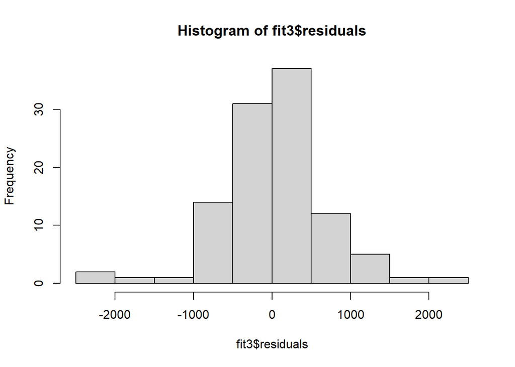

```r
hist(fit3$residuals)
```

```r
accuracy(auto_fit)
```

```
##                    ME     RMSE      MAE      MPE     MAPE      MASE
## Training set 3.581792 661.5281 456.1233 -3.26036 11.41566 0.7433795
##                      ACF1
## Training set -0.005562076
```

```r
accuracy(fit3)
```

```
##                    ME     RMSE      MAE      MPE     MAPE      MASE
## Training set 3.581792 661.5281 456.1233 -3.26036 11.41566 0.7433795
##                      ACF1
## Training set -0.005562076
```

Final summary

The time series data has both seasonal and non-seasonal patterns. ARIMA(p,d,q)(P,D,Q) where

p: Autoregressive order

d: Non-seasonal difference order

q: Moving average order

P: Seasonal autoregressive order

D: Seasonal difference order

Q: Seasonal moving average order

s: Seasonal period